# **ЛАБОРАТОРНА РОБОТА №3**

## **Візуалізація пропусків**

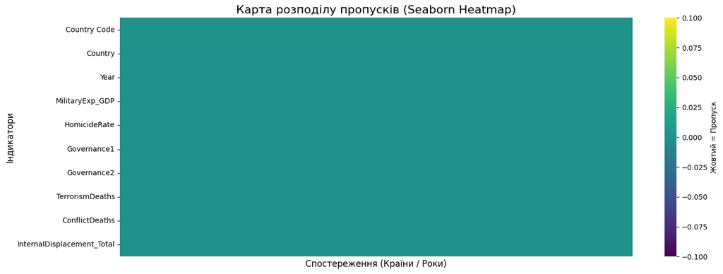

```python
import seaborn as sns
import matplotlib.pyplot as plt

plt.figure(figsize=(16, 6))

sns.heatmap(df.isnull().transpose(),
            cmap="viridis",
            cbar_kws={'label': 'Жовтий = Пропуск'},
            xticklabels=False)

plt.title("Карта розподілу пропусків (Seaborn Heatmap)", fontsize=16)
plt.xlabel("Спостереження (Країни / Роки)", fontsize=12)
plt.ylabel("Індикатори", fontsize=12)
plt.show()
```

### **Оцінка якості даних**

Пропуски відсутні!

## **7.5 Нормалізація даних (StandardScaler)**

Перед застосуванням PCA та кластеризації **обов’язково** потрібно привести всі індикатори до єдиного масштабу, інакше ознаки з більшими числовими значеннями будуть штучно домінувати.

Використовуємо **стандартизацію (z-score нормалізацію)** за формулою:

$$ z = \frac{x - \mu}{\sigma}, $$

де

- x - початкове значення індикатора;
- μ - середнє значення індикатора по всій вибірці;
- σ - стандартне відхилення індикатора;
- z - нормалізоване значення (матиме середнє = 0 і σ = 1);

### Переваги StandardScaler:

- Зберігає розподіл даних
- Добре працює з PCA та більшістю алгоритмів кластеризації
- Не чутливий до викидів так сильно, як MinMaxScaler

```python
# індикатори для аналізу
# Копіюємо дані
X_prepared = df[features].copy()

# Список негативних індикаторів (де більше = гірше)
negative_indicators = [
    "MilitaryExp_GDP",
    "HomicideRate",
    "TerrorismDeaths",
    "ConflictDeaths",
    "InternalDisplacement_Total"
]

# Інвертуємо їх (множимо на -1), щоб високе значення стало низьким
# Тепер для ВСІХ колонок: чим більше число, тим краща безпека.
X_prepared[negative_indicators] = X_prepared[negative_indicators] * -1

# Тепер нормалізуємо
X_clean_scaled = (X_prepared - X_prepared.mean()) / X_prepared.std()

# Створюємо DataFrame з правильними назвами
X_clean_scaled_df = pd.DataFrame(X_clean_scaled, columns=features)


X_clean_scaled_df.head()
```

|  | MilitaryExp_GDP | HomicideRate | Governance1 | Governance2 | TerrorismDeaths | ConflictDeaths | InternalDisplacement_Total |
| --- | --- | --- | --- | --- | --- | --- | --- |
| 0 | 0.001197 | 0.015493 | 0.051371 | 0.055872 | 0.134051 | 0.088568 | 0.168427 |
| 1 | 0.001197 | 0.015493 | 0.051371 | 0.055872 | 0.134051 | 0.088568 | 0.168427 |
| 2 | 0.001197 | 0.015493 | 0.051371 | 0.055872 | 0.134051 | 0.088568 | 0.168427 |
| 3 | 0.001197 | 0.015493 | 0.051371 | 0.055872 | 0.134051 | 0.088568 | 0.168427 |
| 4 | 0.001197 | 0.015493 | 0.051371 | 0.055872 | 0.134051 | 0.088568 | 0.168284 |

Отже нормалізація пройшла успішно.